# Sequential Statistical Methods for Reliable ML — Sulam

## Coverage through betting

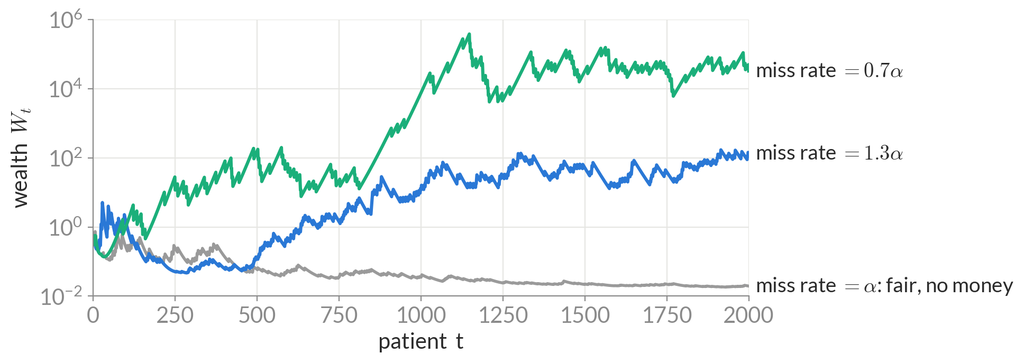

A universal portfolio strategy (for choosing $\lambda_t$; a mixture over all constant bets) nearly matches the best constant bet:

$$\ln W_T \ \ge\ \max_\lambda \ln W_T(\lambda) - \tfrac12\ln(\pi T)$$

[Cover, 1991][Cover & Ordentlich, 1996]

## Coverage through betting (proof sketch)

**Idea:** choose the interval size so that the bettor cannot make money.

$$\tau_t := \lambda_t\, W_{t-1} \qquad\text{(the amount bet on a miss)}$$

Then $\ W_t = W_{t-1} - \tau_t\, g_t$, $\quad$ so $\quad W_T = 1 - \sum_{t\le T} \tau_t\, g_t$.

**If coverage is wrong** ($\varepsilon_T \ne 0$)**, the wealth grows:**
$$\ln W_T \ \gtrsim\ \frac{\varepsilon_T^2\, T}{2\alpha(1-\alpha)} - \tfrac12\ln(\pi T)$$

**But the wealth is bounded by the scores:**
$$-\tau_t g_t \le (1-\alpha)\,S_t \quad\Longrightarrow\quad W_T \le 1 + (1-\alpha)\sum_{t\le T} S_t$$

So: $\qquad |\varepsilon_T| = \mathcal O\big(\sqrt{\ln T / T}\big) \qquad \text{whenever } S_t \le D\,t^q$

[Orabona & Pál, 2016][Liu, Dobriban & Orabona, 2026 (UP-OCP)]

## Coverage for every group

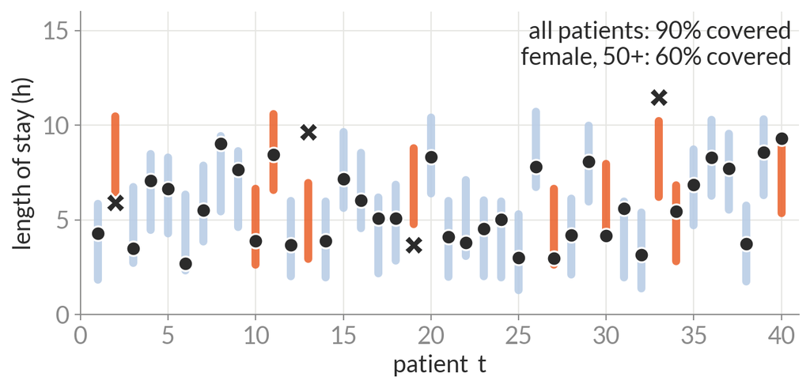

For groups $c_1,\dots,c_k$ with $T_j = \sum_{t\le T} c_j(X_t)$, we want, for every $j$,
$$\frac{1}{T_j}\sum_{t=1}^T \mathbf 1\{S_t \le \tau_t\}\, c_j(X_t)\ \longrightarrow\ 1-\alpha$$

## From one group to many

As before, a goal for every group $j$, with $T_j = \sum_{t\le T} c_j(X_t)$:

$$\frac{1}{T_j}\sum_{t=1}^T \mathbf 1\{S_t \le \tau_t\}\, c_j(X_t)\ \longrightarrow\ 1-\alpha$$

As before, one betting game per group.

Bettor $j$ makes money if group $j$ is mis-covered.

**But** it can’t, because we adapt the radius: $\ \tau_{t,j} = \lambda_{t,j}\, W_{t-1,j}$.

**Problem:** this provides as many radii as groups a sample belongs to.

[Liu, Dobriban & Orabona, 2026]

## POGO: one bettor per group

Portfolios for Online Group cOnformal prediction

Radius linear in group membership, as in GCACI Ramalingam et al, 2025:

$$\tau_t(X_t) = \langle \theta_t,\ c(X_t)\rangle = \theta_{\text{X-ray}}\, c_{\text{X-ray}}(X_t) + \theta_{50+}\, c_{50+}(X_t) + \cdots$$

- one universal-portfolio bettor per group, starting with $W_{0,j} = 1/k$
- group $j$ only plays when present: $\ g_{t,j} = g_t\, c_j(X_t)$
- each bettor sets one coordinate: $\ \theta_{t,j} = W_{t-1,j}\,\lambda_{t,j}$ (controls $\sum_j W_{t,j}$)

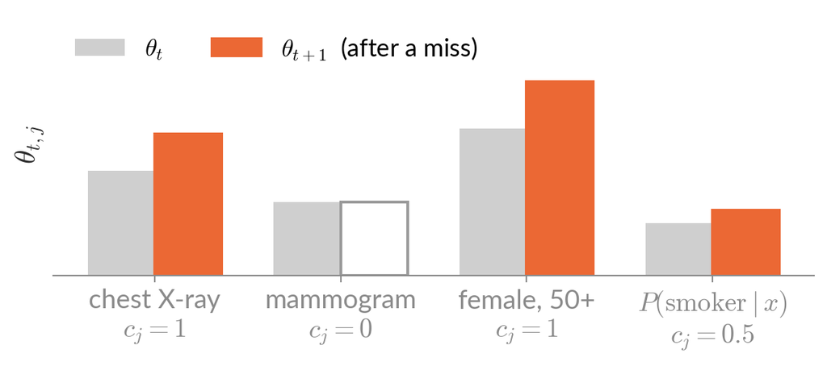

[Ramalingam et al, 2025][Bharti, Pal, Teneggi, S., 2026]

## POGO: coverage guarantee

Theorem [Bharti, Pal, Teneggi, S.] If $S_t \le D\,t^q$, then for every group $j$
$$\MisCov_T(j)\ \lesssim\ \sqrt{\frac{2\alpha(1-\alpha)\,L}{T_j}} + \frac{L}{T_j}, \qquad L = \ln T + \ln k + C$$
$\ln T$ from the bound on the wealth and the universal portfolio, $\ln k$ from starting at $1/k$; $C$ depends on $D, q, \alpha$. Full statement in backup.

For $T_j \asymp \rho_j T$: $\ \MisCov_T(j) = \mathcal O\big(\sqrt{\alpha\ln(kT)/T} + \ln(kT)/T\big)$.

|  | group miscoverage | tuning | scores |
| --- | --- | --- | --- |
| GCACI | $\mathcal O\big(\sqrt{(k + 1/\eta)/T}\big)$ | $\eta$ | bounded |
| UP-OCP (marginal only) | $\mathcal O\big(\sqrt{\alpha\ln T/T} + \ln T/T\big)$ | none | $S_t \le D\,t^q$ |
| **POGO** | $\mathcal O\big(\sqrt{\alpha\ln(kT)/T} + \ln(kT)/T\big)$ | none | $S_t \le D\,t^q$ |

[Ramalingam et al, 2025][Angelopoulos et al, 2025][Liu et al, 2026]

## POGO: coverage guarantee

Theorem [Bharti, Pal, Teneggi, S.] If $S_t \le D\,t^q$, then for every group $j$
$$\MisCov_T(j)\ \lesssim\ \sqrt{\frac{2\alpha(1-\alpha)\,L}{T_j}} + \frac{L}{T_j}, \qquad L = \ln T + \ln k + C$$
$\ln T$ from the bound on the wealth and the universal portfolio, $\ln k$ from starting at $1/k$; $C$ depends on $D, q, \alpha$. Full statement in backup.

✓ no step size to tune  
✓ marginal coverage included (add a group with everyone, $c_0 \equiv 1$)

## Simulation: a shift in a rare group

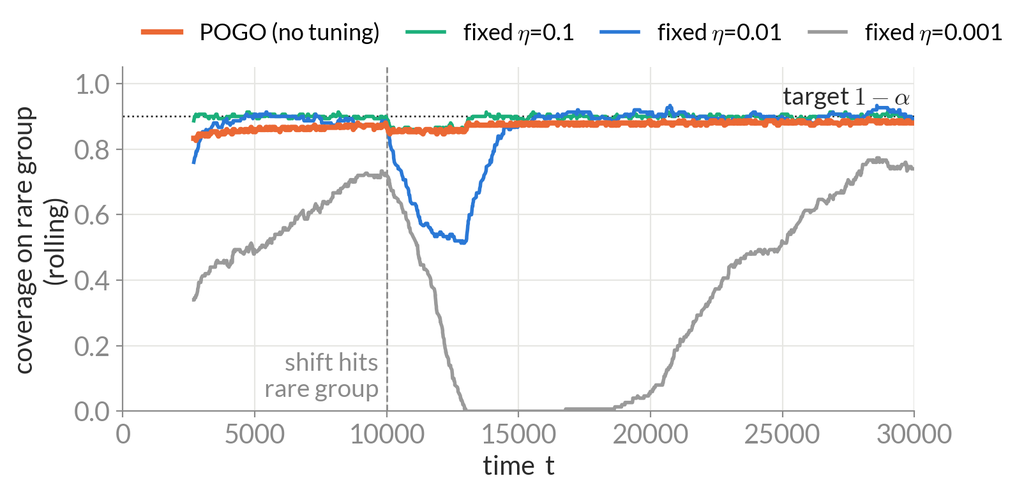

$k=10$ groups; at $t=10^4$ the scores of a rare group (5% of patients) jump

|  | POGO | $\eta=0.1$ | $\eta=0.01$ | $\eta=0.001$ |
| --- | --- | --- | --- | --- |
| mean radius | 0.18 | 0.24 | 0.18 | 0.18 |
| jump per step | 0.01 | 0.09 | 0.02 | 0.02 |

## ICU length of stay and stock prices

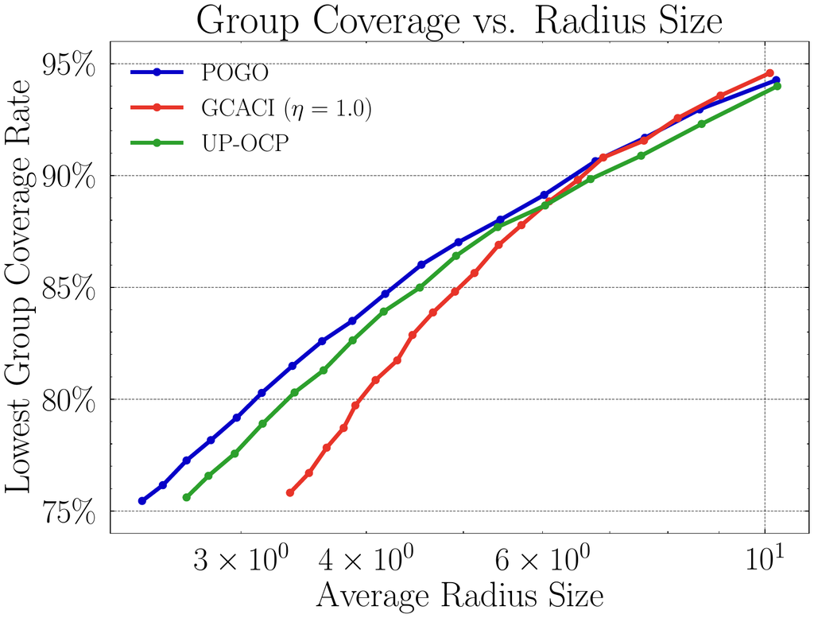

MIMIC-IV length of stay; groups by race, insurance, sex

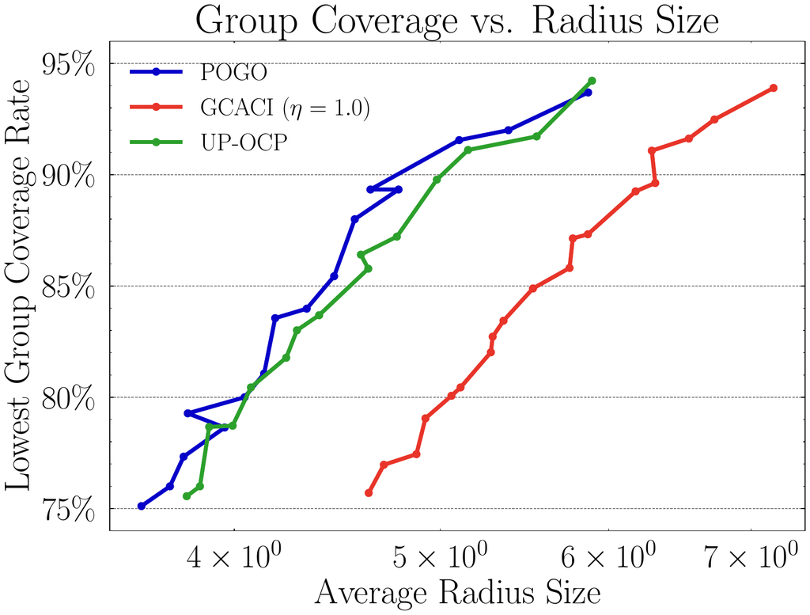

Delta (DAL) daily opening price

lowest group coverage vs. average radius, target $1-\alpha$ from 0.75 to 0.95; up and to the left is better

## Take-home messages

- Auditing and uncertainty quantification after deployment are sequential problems; betting gives anytime-valid answers.
- **Auditing $k$ groups:** a balanced merge of the wealth is fast whether one group or many are non-null.
- **Online conformal:** set the interval width by betting; coverage holds on every group, for any sequence, with no step size.

## Thank you

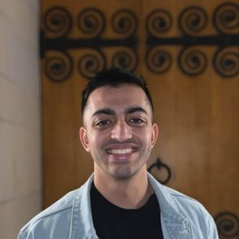

Beepul Bharti JHU

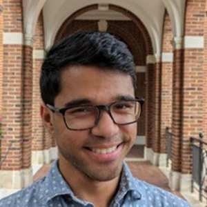

Ambar Pal Amazon

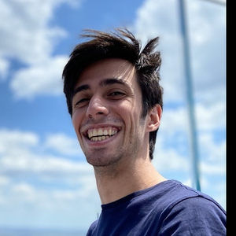

Jacopo Teneggi JHU

**Global Sequential Testing for Multi-Stream Auditing**  
arXiv:2602.21479

**Parameter-Free and Group Conditional Online Conformal Prediction**  
arXiv:2606.00419

Supported by NSF CAREER award 2239787 and NIH/NCI R01CA287422.

[figure not shown]

[figure not shown]